# LBB - Unveiling Socio Demographic Patterns: Exploring Data Panels with plm() in R

### 2.2.1 Penyesuaian Struktur Data

**1. Membuat Panel Data Frame**

Agar data kita dapat melakukan balancing, kita perlu mengubah format data yang kita miliki menjadi sebuah panel data frame terlebih dahulu. Untuk memembuat panel data frame dapat kita lakukan dengan fungsi `pdata.frame()` dengan parameter:

- `data` : data yang akan digunakan
- `index` : c(“informasi individu”,“informasi waktu”)

```r
#membuat pdata.frame
df_asia <- df_asia %>% pdata.frame(index=c("Country.Name","Year"))

#memeriksa struktur data
glimpse(df_asia)
```

```
#> Rows: 80
#> Columns: 12
#> $ Country.Name                      <fct> China, China, China, China, China, C…
#> $ Year                              <fct> 2006, 2007, 2008, 2009, 2010, 2011, …
#> $ Life.Ladder                       <pseries> 4.560495, 4.862862, 4.846295, 4.…
#> $ Log.GDP.Per.Capita                <pseries> 8.696139, 8.823968, 8.910974, 8.…
#> $ Social.Support                    <pseries> 0.7470113, 0.8108524, 0.7482873,…
#> $ Healthy.Life.Expectancy.At.Birth  <pseries> 65.660, 65.920, 66.180, 66.440, …
#> $ Freedom.To.Make.Life.Choices      <pseries> NA, NA, 0.8530720, 0.7711433, 0.…
#> $ Generosity                        <pseries> NA, -0.17888285, -0.09518377, -0…
#> $ Perceptions.Of.Corruption         <pseries> NA, NA, NA, NA, NA, NA, NA, NA, …
#> $ Positive.Affect                   <pseries> 0.6576588, 0.6639774, 0.7051333,…
#> $ Negative.Affect                   <pseries> 0.1695804, 0.1586135, 0.1469630,…
#> $ Confidence.In.National.Government <pseries> NA, NA, NA, NA, NA, NA, NA, NA, …
```

Dengan pengubahan tipe data menjadi pdata.frame akan otomatis mengubah type data dari setiap kolom,

- kolom yang dijadikan index akan bertipe factor
- selain kolom index akan menjadi pseries

**2. Mememeriksa Dimensi Data**

untuk memeriksa dimendi data panel dapat kita gunakan fungsi `pdim()`

```r
# Your Code Here
pdim(df_asia)
```

```
#> Unbalanced Panel: n = 5, T = 15-17, N = 80
```

dari pemeriksaan dimensi data panel diatas dapat kita ketahui bahwa:

- Kita memiliki 5 individu/negara
- Datanya berjumlah 15-17 (belum balanced)

### 2.2.2 Balancing Data

Apabila data panel yang kita miliki tidak *balance* kita dapat melakukan balancing menggunakan fungsi `make.pbalanced` dengan parameter `balance.type` yang dapat diisi dengan 3 opsi berikut:

1. `fill` : untuk setiap kolom waktu yg hilang akan diberikan nilai NA
2. `shared.times` : akan diambil keseluruhan individu dgn ketentuan informasi waktu terdapat di semua individu
3. `shared.individuals` : akan individu dengan ketentuan informasi waktu lengkap

**1. Balancing menggunakan fill**

```r
# Your Code Here
balance1 <- df_asia %>% make.pbalanced(balance.type = "fill")
table(balance1$Country.Name)
```

```
#>
#>                    China                    Japan                 Mongolia
#>                       18                       18                       18
#>              South Korea Taiwan Province of China
#>                       18                       18
```

**2. Balancing menggunakan shared.times**

```r
# Your Code Here
balance2 <- df_asia %>% make.pbalanced(balance.type = "shared.times")
table(balance2$Country.Name)
```

```
#>
#>                    China                    Japan                 Mongolia
#>                       13                       13                       13
#>              South Korea Taiwan Province of China
#>                       13                       13
```

**3. Balancing menggunakan shared.individuals**

```r
# Your Code Here
balance3 <- df_asia %>% make.pbalanced(balance.type = "shared.individuals")
table(balance3$Country.Name)
```

```
#>
#>                    China                    Japan                 Mongolia
#>                        0                        0                        0
#>              South Korea Taiwan Province of China
#>                        0                        0
```

Berdasarkan kondisi data yang dimiliki, kita akan menggunakan data hasil balancing dengan metode `fill` untuk mendapatkan informasi paling optimal yang akan tersimpan pada objek bernama `balance1`.

```r
# Periksa kembali keseimbangan data
is.pbalanced(balance1)
```

```
#> [1] TRUE
```

```r
# pengecekan kembali dimensi data
pdim(balance1)
```

```
#> Balanced Panel: n = 5, T = 18, N = 90
```

## 2.3 Pemeriksaan Missing Value

sebelum kita periksa kelengkapan data kita perlu mengetahui berapa banyak informasi waktu yang ditambahkan dari tahapan sebelumnya

```r
colSums(is.na(balance1)) - colSums(is.na(df_asia))
```

```
#>                      Country.Name                              Year
#>                                 0                                 0
#>                       Life.Ladder                Log.GDP.Per.Capita
#>                                10                                10
#>                    Social.Support  Healthy.Life.Expectancy.At.Birth
#>                                10                                10
#>      Freedom.To.Make.Life.Choices                        Generosity
#>                                10                                10
#>         Perceptions.Of.Corruption                   Positive.Affect
#>                                10                                10
#>                   Negative.Affect Confidence.In.National.Government
#>                                10                                10
```

berdasarkan pemeriksaan diatas dapat diketahui bahwa dari data df_asia ketika dilakukan balancing terjadi penambahan 10 baris nilai NA untuk setiap kolom.

Tahap selanjutnya adalah memeriksa kelengkapan data hasil balancing

```r
colSums(is.na(balance1))
```

```
#>                      Country.Name                              Year
#>                                 0                                 0
#>                       Life.Ladder                Log.GDP.Per.Capita
#>                                10                                13
#>                    Social.Support  Healthy.Life.Expectancy.At.Birth
#>                                10                                22
#>      Freedom.To.Make.Life.Choices                        Generosity
#>                                15                                17
#>         Perceptions.Of.Corruption                   Positive.Affect
#>                                26                                10
#>                   Negative.Affect Confidence.In.National.Government
#>                                10                                30
```

Berdasarkan hasil pemeriksaan diatas kita melihat secara keseluruhan terdapat cukup banyak kolom yang memiliki nilai missing

```r
balance1 <- balance1%>%select(-Confidence.In.National.Government,-Healthy.Life.Expectancy.At.Birth,-Perceptions.Of.Corruption)
```

Untuk pemeriksaan dan melakukan pengisian nilai yang hilang maka akan dilakukan dengan cara interpolasi secara terpisah untuk setiap negara.

**1. China**

```r
# periksa nilai missing per negara
chn <- balance1 %>% filter(Country.Name=="China")
colSums((is.na(chn)))
```

```
#>                 Country.Name                         Year
#>                            0                            0
#>                  Life.Ladder           Log.GDP.Per.Capita
#>                            2                            2
#>               Social.Support Freedom.To.Make.Life.Choices
#>                            2                            7
#>                   Generosity              Positive.Affect
#>                            3                            2
#>              Negative.Affect
#>                            2
```

insight: `Freedom.To.Make.Life.Choices` memiliki nilai na paling banyak = 7

untuk mengisi nilai yang hilang dengan nilai rata-rata dari nilai yang dekat dengan nilai missing menggunakan fungsi `na.fill()` dengan `fill = "extend"`

```r
# mengisi nilai missing
chn <- chn %>% mutate(Life.Ladder=na.fill(Life.Ladder,fill="extend"),
                      Log.GDP.Per.Capita =na.fill(Log.GDP.Per.Capita,fill="extend"),
                      Social.Support=na.fill(Social.Support,fill="extend"),
                      Freedom.To.Make.Life.Choices=na.fill(Freedom.To.Make.Life.Choices,fill="extend"),
                      Generosity=na.fill(Generosity,fill="extend"),
                      Positive.Affect=na.fill(Positive.Affect,fill="extend"),
                      Negative.Affect=na.fill(Negative.Affect,fill="extend")
                      )

anyNA(chn)
```

```
#> [1] FALSE
```

**2. Japan**

```r
# periksa nilai missing per negara
jpn <- balance1 %>% filter(Country.Name=="Japan")
colSums((is.na(jpn)))
```

```
#>                 Country.Name                         Year
#>                            0                            0
#>                  Life.Ladder           Log.GDP.Per.Capita
#>                            1                            1
#>               Social.Support Freedom.To.Make.Life.Choices
#>                            1                            1
#>                   Generosity              Positive.Affect
#>                            3                            1
#>              Negative.Affect
#>                            1
```

insight: `Generossity` memiliki nilai na paling banyak = 3

```r
# mengisi nilai missing
jpn <- jpn %>% mutate(Life.Ladder=na.fill(Life.Ladder,fill="extend"),
                      Log.GDP.Per.Capita =na.fill(Log.GDP.Per.Capita,fill="extend"),
                      Social.Support=na.fill(Social.Support,fill="extend"),
                      Freedom.To.Make.Life.Choices=na.fill(Freedom.To.Make.Life.Choices,fill="extend"),
                      Generosity=na.fill(Generosity,fill="extend"),
                      Positive.Affect=na.fill(Positive.Affect,fill="extend"),
                      Negative.Affect=na.fill(Negative.Affect,fill="extend")
                      )

anyNA(jpn)
```

```
#> [1] FALSE
```

**3. Mongolia**

```r
# periksa nilai missing per negara
mon <- balance1 %>% filter(Country.Name == "Mongolia")
colSums(is.na(mon))
```

```
#>                 Country.Name                         Year
#>                            0                            0
#>                  Life.Ladder           Log.GDP.Per.Capita
#>                            3                            3
#>               Social.Support Freedom.To.Make.Life.Choices
#>                            3                            3
#>                   Generosity              Positive.Affect
#>                            3                            3
#>              Negative.Affect
#>                            3
```

insight: Mongolia memiliki nilai na sama untuk semua field = 3

```r
# mengisi nilai missing
mon <- mon %>% mutate(Life.Ladder=na.fill(Life.Ladder,fill="extend"),
                      Log.GDP.Per.Capita =na.fill(Log.GDP.Per.Capita,fill="extend"),
                      Social.Support=na.fill(Social.Support,fill="extend"),
                      Freedom.To.Make.Life.Choices=na.fill(Freedom.To.Make.Life.Choices,fill="extend"),
                      Generosity=na.fill(Generosity,fill="extend"),
                      Positive.Affect=na.fill(Positive.Affect,fill="extend"),
                      Negative.Affect=na.fill(Negative.Affect,fill="extend")
                      )

anyNA(mon)
```

```
#> [1] FALSE
```

**4. South Korea**

```r
# periksa nilai missing per negara
skr <- balance1 %>% filter(Country.Name == "South Korea")
colSums(is.na(skr))
```

```
#>                 Country.Name                         Year
#>                            0                            0
#>                  Life.Ladder           Log.GDP.Per.Capita
#>                            1                            1
#>               Social.Support Freedom.To.Make.Life.Choices
#>                            1                            1
#>                   Generosity              Positive.Affect
#>                            2                            1
#>              Negative.Affect
#>                            1
```

insight : `Generossity` memiliki nilai na paling banyak = 2

```r
# mengisi nilai missing
skr <- skr %>% mutate(Life.Ladder=na.fill(Life.Ladder,fill="extend"),
                      Log.GDP.Per.Capita =na.fill(Log.GDP.Per.Capita,fill="extend"),
                      Social.Support=na.fill(Social.Support,fill="extend"),
                      Freedom.To.Make.Life.Choices=na.fill(Freedom.To.Make.Life.Choices,fill="extend"),
                      Generosity=na.fill(Generosity,fill="extend"),
                      Positive.Affect=na.fill(Positive.Affect,fill="extend"),
                      Negative.Affect=na.fill(Negative.Affect,fill="extend")
                      )

anyNA(skr)
```

```
#> [1] FALSE
```

**5. Taiwan Province of China**

```r
# periksa nilai missing per negara
tw <- balance1 %>% filter(Country.Name == "Taiwan Province of China")
colSums(is.na(tw))
```

```
#>                 Country.Name                         Year
#>                            0                            0
#>                  Life.Ladder           Log.GDP.Per.Capita
#>                            3                            6
#>               Social.Support Freedom.To.Make.Life.Choices
#>                            3                            3
#>                   Generosity              Positive.Affect
#>                            6                            3
#>              Negative.Affect
#>                            3
```

insight: `Generossity` dan `Log.GDP.Per.Capita` memiliki nilai na paling banyak = 6

```r
#mengisi nilai missing
tw <- tw %>% mutate(Life.Ladder=na.fill(Life.Ladder,fill="extend"),
                      Log.GDP.Per.Capita =na.fill(Log.GDP.Per.Capita,fill="extend"),
                      Social.Support=na.fill(Social.Support,fill="extend"),
                      Freedom.To.Make.Life.Choices=na.fill(Freedom.To.Make.Life.Choices,fill="extend"),
                      Generosity=na.fill(Generosity,fill="extend"),
                      Positive.Affect=na.fill(Positive.Affect,fill="extend"),
                      Negative.Affect=na.fill(Negative.Affect,fill="extend")
                      )

anyNA(tw)
```

```
#> [1] FALSE
```

Setelah semua negara tidak lagi terdapat nilai yang missing, selanjutnya kita akan gabungkan kembali dan akan disimpan pada objek dengan nama balanced2

```r
# Your Code Here
balanced2 <- bind_rows(chn,jpn,mon,skr,tw)
```

Pemeriksaan Kembali keseimbangan data

```r
# Your Code Here
pdim(balanced2)
```

```
#> Balanced Panel: n = 5, T = 18, N = 90
```

Pemeriksaan Kembali kelengkapan data

```r
# Your Code Here
colSums(is.na(balanced2))
```

```
#>                 Country.Name                         Year
#>                            0                            0
#>                  Life.Ladder           Log.GDP.Per.Capita
#>                            0                            0
#>               Social.Support Freedom.To.Make.Life.Choices
#>                            0                            0
#>                   Generosity              Positive.Affect
#>                            0                            0
#>              Negative.Affect
#>                            0
```

Data telah siap untuk digunakan pada tahapan selanjutnya

## 2.4 Exploratory Data Analysis

### 2.4.1 Ringkasan Data

```r
summary(balanced2)
```

```
#>                    Country.Name      Year     Life.Ladder    Log.GDP.Per.Capita
#>  China                   :18    2005   : 5   Min.   :4.454   Min.   : 8.696
#>  Japan                   :18    2006   : 5   1st Qu.:5.157   1st Qu.: 9.365
#>  Mongolia                :18    2007   : 5   Median :5.854   Median :10.513
#>  South Korea             :18    2008   : 5   Mean   :5.671   Mean   :10.058
#>  Taiwan Province of China:18    2009   : 5   3rd Qu.:6.115   3rd Qu.:10.629
#>                                 2010   : 5   Max.   :6.947   Max.   :10.797
#>                                 (Other):60
#>  Social.Support   Freedom.To.Make.Life.Choices   Generosity
#>  Min.   :0.7378   Min.   :0.4841               Min.   :-0.26659
#>  1st Qu.:0.8080   1st Qu.:0.6831               1st Qu.:-0.15041
#>  Median :0.8738   Median :0.7526               Median :-0.05837
#>  Mean   :0.8551   Mean   :0.7426               Mean   :-0.05856
#>  3rd Qu.:0.9017   3rd Qu.:0.8145               3rd Qu.: 0.02133
#>  Max.   :0.9513   Max.   :0.9274               Max.   : 0.21715
#>
#>  Positive.Affect  Negative.Affect
#>  Min.   :0.4832   Min.   :0.08274
#>  1st Qu.:0.5632   1st Qu.:0.14773
#>  Median :0.6696   Median :0.17507
#>  Mean   :0.6437   Mean   :0.17850
#>  3rd Qu.:0.7050   3rd Qu.:0.20653
#>  Max.   :0.7792   Max.   :0.33815
#>
```

### 2.4.2 Hubungan Antar Variabel

Untuk mengetahui seberapa besar tingkat hubungan antar variabel prediktor terhadap variabel target, dapat kita gunakan fungsi `ggcorrplot`.

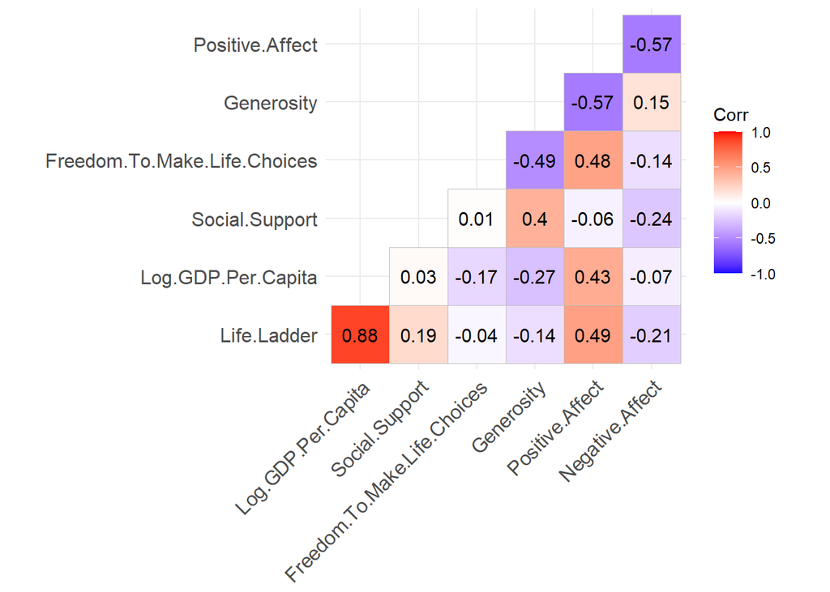

```r
# Your Code Here
balanced2 %>% select(-Country.Name,-Year) %>%cor()%>%ggcorrplot(type="lower",lab=TRUE)
```

Berdasarkan hasil plot heatmap diatas, dapat diketahui bahwa

- Variabel yang memiliki Hubungan Kuat terhadap Life.Ladder adalah:
  - Log.GDP.Per.Capita
  - Positive Affect
- Terdapat indikasi multikolinieritas antara
  - Log.GDP.Per.Capita dengan Life.Ladder

### 2.4.3 Explorasi Socio demografi

Untuk melihat lebih dalam informasi dari data yang kita miliki dapat kita lakukan dengan menggunakan fungsi `coplot()` dengan parameter

- `formula` = diisikan dengan target ~ index1 given index2
- `type` = `"l"` untuk line dan `"b"` untuk point & line plot
- `data` = dataset
- `rows` = banyaknya baris panel plot yang dibuat
- `col` = warna plot yang disajikan

**1. Life.ladder**

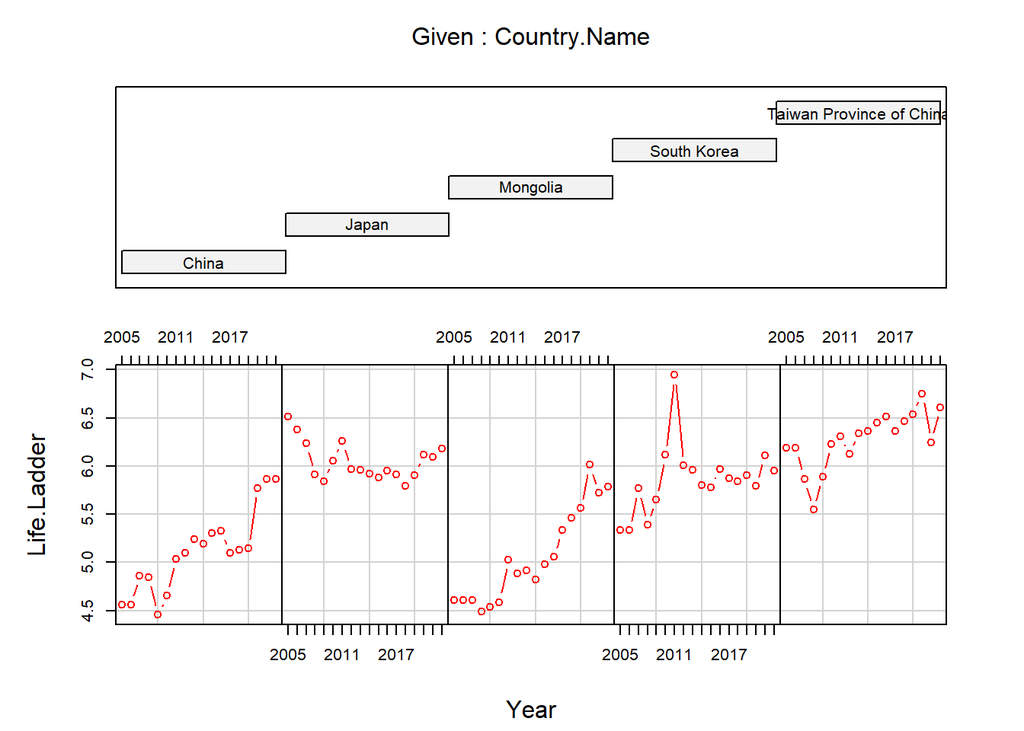

```r
# Your Code Here
coplot(Life.Ladder ~ Year|Country.Name,
       type = "b",
       data = balanced2,
       rows = 1,
       col = "red")
```

Berdasarkan Line plot diatas dapat kita ketahui bahwa :

- South Korea pernah memiliki life.ladder yang paling tinggi sekitar tahun 2011. Tahun tersebut merupakan tahun keemasan K-waves di bidang K-Drama, girl group, boy band dll.
- Mongolia dan China memiliki trend life-ladder yang serupa

**2. Log.GDP.Per.Capita**

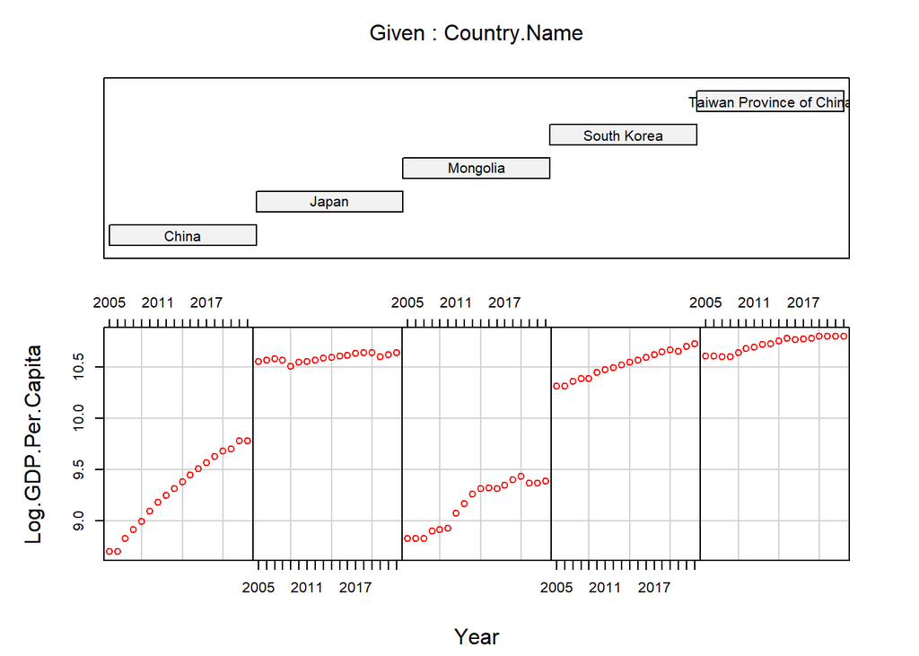

```r
# Your Code Here
coplot(Log.GDP.Per.Capita ~ Year|Country.Name,
       type = "b",
       data = balanced2,
       rows = 1,
       col = "red")
```

Berdasarkan plot diatas dapat kita ketahui bahwa :

- Jepang, Korea Selatan dan Taiwan memiliki gdp jauh meninggalkan China dan Mongolia
- GDP China rendah karena memiliki penduduk terbanyak di dunia

**3. Social.Support**

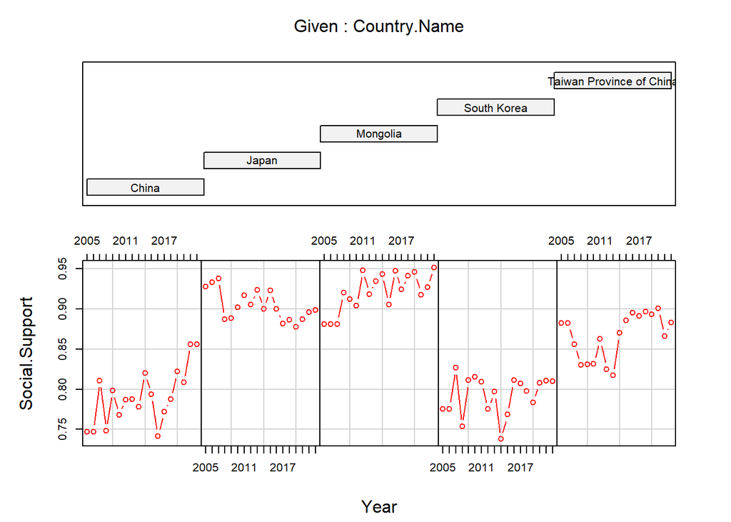

```r
# Your Code Here
coplot(Social.Support ~ Year|Country.Name,
       type = "b",
       data = balanced2,
       rows = 1,
       col = "red")
```

Berdasarkan plot diatas dapat kita ketahui bahwa :

- Social Support Jepang dan Mongolia berada di tingkat tertinggi
- Social Support Taiwan di tingkat menengah
- Social Support China dan Korea Selatan di bawah

**4. Freedom.To.Make.Life.Choices**

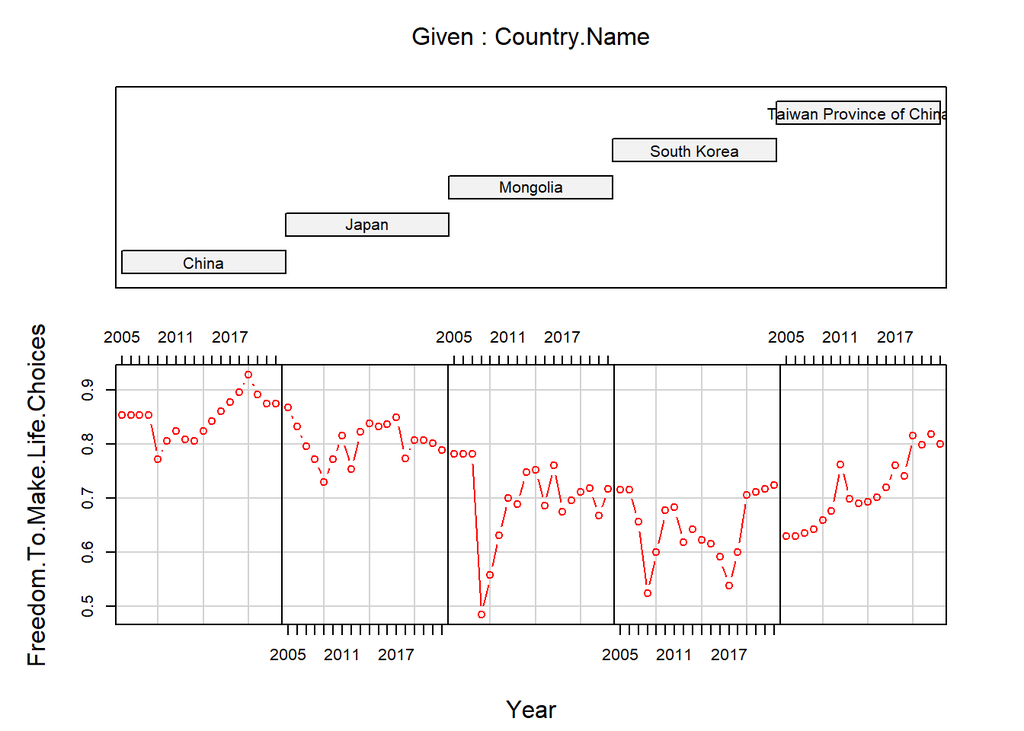

```r
# Freedom.To.Make.Life.Choices
coplot(Freedom.To.Make.Life.Choices ~ Year|Country.Name,
       type = "b",
       data = balanced2,
       rows = 1,
       col = "red")
```

Berdasarkan Line plot diatas dapat kita ketahui bahwa :

- Tidak disangka, China berada di peringkat teratas dalam kategori `Freedom.To.Make.Life.Choices`. Padahal, China terkenal dengan sistem komunis nya
- Mongolia dan Korea Selatan berada di peringkat terbawah dalam kategori `Freedom.To.Make.Life.Choices`

### 2.4.4 Heterogenitas Life.Ledder

Untuk melihat heterogenitas antar individu dan waktu kita dapat menggunakan fungsi `plotmeans()` dari package gplots dengan parameter:

- formula : Target ~ variabel index individu/waktu
- data : data frame

**1. Heterogenitas antar negara**

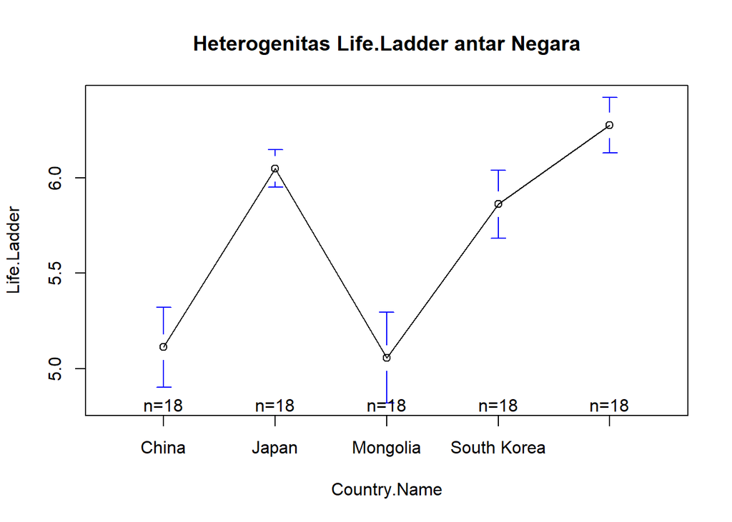

```r
plotmeans( Life.Ladder ~ Country.Name, data = balanced2, main="Heterogenitas Life.Ladder antar Negara")
```

Insight : Taiwan, Korea Selatan dan Jepang memiliki tingkat `life.ladder` yang tinggi. Sedangkan China dan Mongolia, jauh ketinggalan di bawah.

**2. Heterogenitas antar Waktu**

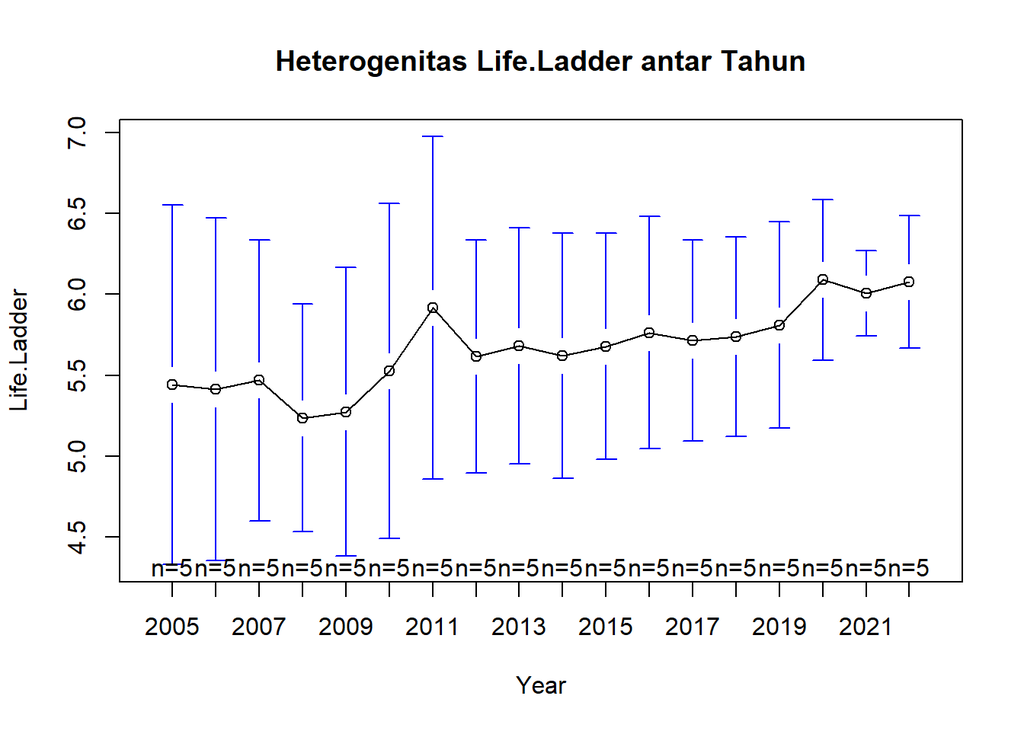

```r
plotmeans(Life.Ladder ~ Year, data = balanced2, main="Heterogenitas Life.Ladder antar Tahun")
```

Insight : Tahun 2011,2020-2022 adalah tahun dimana orang dari beberapa negara di Asia Timur paling bahagia di rentang tahun 2005-2022.

## 2.5 Pemodelan

### 2.5.1 Cross-Validation

Tahapan cross validation akan selalu dilakukan sebelum pembuatan model, data akan dibagi menjadi data train dan data test. Dikarenakan data panel memiliki informasi keterangan waktu maka pembagian data tidak boleh diambil secara acak melainkan dibagi dengan cara dipisah secara berurutan.

- Data Train akan menggunakan data yang terlampau
- Data Test akan menggunakan data yang terbaru

untuk melakukannya kita bisa menggunakan bantuan fungsi `filter()`

```r
#membuat data train
ladder_train <- balanced2 %>% filter(Year != 2022)

#membuat data test
ladder_test <- balanced2 %>% filter(Year == 2022)
```

setelah dilakukan cross validation kita perlu memastikan kembali bahwa data train sudah balance dengan melakukan balancing

```r
ladder_train <- ladder_train %>%
  droplevels() %>%    # menghapus informasi waktu yang diambil sebagai data test (tahun 2022)
  make.pbalanced()    # melakukan balancing kembali

is.pbalanced(ladder_train)
```

```
#> [1] TRUE
```

### 2.5.2 Pemeriksaan Asumsi Multikolinieritas

Dikarenakan pada hasil pemeriksaan korelasi pada tahapan EDA sebelumnya menunjukkan adanya indikasi multikolinieritas antar variabel prediktor, maka akan dilakukan pemeriksaan asumsi multikolinieritas terlebih dahulu dengan cara pembuatan model regresi dengan fungsi `lm()` dan dilanjutkan pengujian menggunakan fungsi `vif()`.

nilai VIF > 10: terjadi multicollinearity pada model nilai VIF < 10: tidak terjadi multicollinearity pada model

```r
# your code here
lm(Life.Ladder ~ .-Country.Name -Year, ladder_train) %>% vif()
```

```
#>           Log.GDP.Per.Capita               Social.Support
#>                     2.263397                     1.663773
#> Freedom.To.Make.Life.Choices                   Generosity
#>                     2.560800                     2.430170
#>              Positive.Affect              Negative.Affect
#>                     4.284035                     2.228092
```

Insight: Tidak ada yang memiliki nilai di atas 10 sehingga kita bisa menggunakan semua prediktor yang telah dipersiapkan sebelumnya.

### 2.5.3 Penentuan Model Estimasi

#### 2.5.3.1 Pembuatan Model

Untuk setiap pembuatan model akan digunakan fungsi `plm()` dari package plm dengan parameter sebagai berikut:

- `formula` = Target ~ Prediktor
- `data` = berupa dataframe
- `index` = c(“kolom_individu”,“kolom_waktu”)
- `model` =
  - `"pooling"` : untuk model CEM
  - `"within"` : untuk model FEM
  - `"random"` : untuk model REM

**Model Gabungan (CEM)**

membuat Common effect model dan disimpan kedalam objek `cem`

```r
# membuat Common effect model
cem <- plm(Life.Ladder ~ Log.GDP.Per.Capita + Social.Support + Freedom.To.Make.Life.Choices + Generosity + Positive.Affect + Negative.Affect,
           data = ladder_train,
           index = c("Country.Name","Year"),
           model = "pooling")
```

**Model Pengaruh Tetap (FEM)**

```r
# membuat fixed effect model
fem <- plm(Life.Ladder ~ Log.GDP.Per.Capita + Social.Support + Freedom.To.Make.Life.Choices + Generosity + Positive.Affect + Negative.Affect,
           data = ladder_train,
           index = c("Country.Name","Year"),
           model = "within")
```

**Uji Chow**

Uji chow dilakukan untuk memilih model terbaik antara model gabungan (cem) dengan model fixed effec (fem). untuk melakukan uji Chow dapat menggunakan fungsi `pooltest(model_cem, model_fem)`

Hipotesis yang diuji adalah sebagai berikut:

- H0 : Model gabungan
- H1 : Model pengaruh tetap

H0 ditolak jika P-value < α. Nilai α yang digunakan sebesar 5%.

```r
# your code here
pooltest(cem,fem)
```

```
#>
#>  F statistic
#>
#> data:  Life.Ladder ~ Log.GDP.Per.Capita + Social.Support + Freedom.To.Make.Life.Choices +  ...
#> F = 2.7441, df1 = 4, df2 = 74, p-value = 0.03463
#> alternative hypothesis: unstability
```

Berdasarkan hasil uji chow diatas, kita peroleh nilai p-value < α. artinya Model terbaik untuk digunakan pada data World Happines adalah fixed effect model.

**Model Pengaruh Acak (REM)**

membuat random effect model dan disimpan kedalam objek `rem`

```r
# membuat random effect model
# Error model random effect karena jumlah variabel prediktor dan target > jumlah index individu
#rem <- plm(Life.Ladder ~ Log.GDP.Per.Capita + Social.Support + Freedom.To.Make.Life.Choices + Generosity + Positive.Affect + Negative.Affect,
#           data = ladder_train,
#           index = c("Country.Name","Year"),
#           model = "random")
```

**Uji Hausman**

- H0 : Model pengaruh acak
- H1 : Model pengaruh tetap

```r
# your code here
#phtest(rem,fem)
```

#### 2.5.3.2 Pengujian Asumsi

**Normalitas**

Hipotesis yang diuji adalah sebagai berikut.

- H0 : Sisaan menyebar normal
- H1 : Sisaan tidak menyebar normal

H0 ditolak jika P-value < α. Nilai α yang digunakan sebesar 5%.

```r
# your code here
fem$residuals %>% shapiro.test()
```

```
#>
#>  Shapiro-Wilk normality test
#>
#> data:  .
#> W = 0.91461, p-value = 0.00003201
```

Berdasarkan hasil pengujian normalitas sisaan diperoleh nilai p-value < 0.05, artinya sisaan menyebar secara TIDAK normal.

**Homogenitas**

Hipotesis yang diuji adalah sebagai berikut.

- H0 : Sisaan memiliki ragam homogen
- H1 : Sisaan tidak memiliki ragam homogen

H0 ditolak jika P-value < α. Nilai α yang digunakan sebesar 5%.

```r
# your code here
fem %>% bptest()
```

```
#>
#>  studentized Breusch-Pagan test
#>
#> data:  .
#> BP = 4.0277, df = 6, p-value = 0.6729
```

Berdasarkan hasil pengujian homogenitas diperoleh nilai p-value > 0.05, artinya sisaan memiliki ragam yang homogen.

**Autokorelasi**

Hipotesis yang diuji adalah sebagai berikut.

- H0 : tidak terjadi autokorelasi pada sisaan
- H1 : terjadi autokorelasi pada sisaan

H0 ditolak jika P-value < α. Nilai α yang digunakan sebesar 5%.

```r
# your code here
fem$residuals %>% Box.test(type = "Ljung-Box")
```

```
#>
#>  Box-Ljung test
#>
#> data:  .
#> X-squared = 11.227, df = 1, p-value = 0.0008064
```

Berdasarkan hasil pengujian autokorelasi diperoleh nilai p-value < 0.05, artinya terjadi permasalahan autokorelasi antar sisaan.

### 2.5.4 Interpretasi Model

**1. Koefisien**

```r
# your code here
summary(fem)
```

```
#> Oneway (individual) effect Within Model
#>
#> Call:
#> plm(formula = Life.Ladder ~ Log.GDP.Per.Capita + Social.Support +
#>     Freedom.To.Make.Life.Choices + Generosity + Positive.Affect +
#>     Negative.Affect, data = ladder_train, model = "within", index = c("Country.Name",
#>     "Year"))
#>
#> Balanced Panel: n = 5, T = 17, N = 85
#>
#> Residuals:
#>      Min.   1st Qu.    Median   3rd Qu.      Max.
#> -0.579882 -0.123936 -0.020388  0.114011  0.918328
#>
#> Coefficients:
#>                              Estimate Std. Error t-value     Pr(>|t|)
#> Log.GDP.Per.Capita            0.88749    0.16275  5.4530 0.0000006255 ***
#> Social.Support                2.27912    1.26491  1.8018      0.07565 .
#> Freedom.To.Make.Life.Choices  1.08858    0.47612  2.2864      0.02510 *
#> Generosity                    0.98735    0.50356  1.9607      0.05367 .
#> Positive.Affect               1.49794    1.10717  1.3529      0.18019
#> Negative.Affect              -1.59825    1.00230 -1.5946      0.11507
#> ---
#> Signif. codes:  0 '***' 0.001 '**' 0.01 '*' 0.05 '.' 0.1 ' ' 1
#>
#> Total Sum of Squares:    9.9668
#> Residual Sum of Squares: 4.0801
#> R-Squared:      0.59063
#> Adj. R-Squared: 0.53531
#> F-statistic: 17.7944 on 6 and 74 DF, p-value: 0.0000000000011927
```

Interpretasi:

$$life.ladder = (0.88749 *
Log.GDP.Per.Capita) + (2.27912 * Social.Support) + (1.08858 *
Freedom.To.Make.Life.Choices) + (0.98735 * Generosity) + (1.49794 *
Positive.Affect) - 1.59825 Negative.Affect + uit$$

**2. Mengekstrak informasi Efek dari model fix**

Untuk mengekstrak informasi efek dari model FEM kita dapat menggunakan fungsi `fixef(model fem)`,

```r
# your code here
fixef(fem)
```

```
#>                    China                    Japan                 Mongolia
#>                  -6.4799                  -6.8878                  -6.5678
#>              South Korea Taiwan Province of China
#>                  -6.4140                  -6.8491
```

Interpretasi:

- tingkat kebahagiaan masyarakat di negara China adalah sebesar -6.4799 apabila tidak terdapat informasi lainnya
- tingkat kebahagiaan masyarakat di negara Japan adalah sebesar -6.8878 apabila tidak terdapat informasi lainnya
- tingkat kebahagiaan masyarakat di negara Mongolia adalah sebesar -6.5678 apabila tidak terdapat informasi lainnya
- tingkat kebahagiaan masyarakat di negara South Korea adalah sebesar -6.4140 apabila tidak terdapat informasi lainnya
- tingkat kebahagiaan masyarakat di negara Taiwan Province of China adalah sebesar -6.8491 apabila tidak terdapat informasi lainnya

### 2.5.5 Prediksi & Evaluasi

Untuk melakukan prediksi akan kita gunakan fungsi `predict()` dengan parameter:

- object = nama model yang kita gunakan
- newdata = data baru yang akan kita prediksi

```r
# your code here
pred <- predict(fem, ladder_test, na.fill = F)
```

Untuk menguji apakah model yang kita miliki sudah baik dalam memprediksi data baru maka kita akan evaluasi dengan menggunakan nilai error, salah satu metric eror yang biasa digunakan adalah MAPE. Kita dapat melakukannya menggunakan fungsi `MAPE()` dengan parameter:

- y_pred = nilai hasil prediksi
- y_true = nilai target asli

```r
# your code here
MAPE(y_pred = pred,
     y_true = ladder_test$Life.Ladder)
```

```
#> [1] 0.04158097
```

Insight: tingkat kesalahan prediski model fem dalam memprediksi nilai baru adalah sebesra 4,16%, artinya model sudah cukup baik untuk digunakan dalam memprediksi data yang baru.

# 3 Kesimpulan & Saran

Saran:

- Untuk meningkatkan tingkat kebahagiaan, negara perlu meningkatkan social.support dan log.gdp-nya, caranya:
  - social support:
    - Buat hotline atau forum untuk menampung keluhan warga
    - Buat hotline atau forum untuk menampung keluhan warga
  - Positive Affect:
    - Menggalakkan praktek meditasi, olahraga dan kegiatan kreatif lainnya
    - Menciptakan lingkungan yang ramah
  - Freedom To Make Life Choices:
    - Meningkatkan akses pendidikan dan pelatihan keterampilan untuk semua orang
    - Memastikan adanya kebijakan yang mendukung kebebasan individu untuk membuat pilihan hidup mereka sendiri
  - Generosity:
    - Mendorong sikap berbagi
    - Menggalang dana untuk tujuan sosial
  - log gdp:
    - training center untuk meningkatkan keterampilan masyarakat
    - mendorong pembangunan ekonomi

# 4 Reference

1. Dataset:
   - [BPS RI](https://www.bps.go.id/id)
   - [World Happiness Report 2023](https://www.kaggle.com/datasets/usamabuttar/world-happiness-report-2005-present)
2. [Principles of Econometrics with R](https://bookdown.org/ccolonescu/RPoE4/)
3. [Panel data Econometrics in R](https://cran.r-project.org/web/packages/plm/vignettes/A_plmPackage.html)
4. [Liniear Model for Panel Data](https://cran.r-project.org/web/packages/plm/plm.pdf)
5. [Panel data using R](https://www.princeton.edu/~otorres/Panel101R.pdf)